# GLM: Goodness of Fit and Deviance

Rebecca Gill

2026-05-17

← Back to Index

This page is built in R Markdown. Most code chunks are hidden by default, but you can click ‘show’ to see the code that loads the libraries and generates the data, figures, and tables. The code is also available in my [studycourts/gradData GitHub repository](https://github.com/studycourts/gradData/tree/main/pages).

[figure not shown]

```r
P <- c(
  "knitr",          # rendering
  "kableExtra",     # table formatting
  "texreg",         # htmlreg() for model tables
  "rcompanion",     # nagelkerke() pseudo-R²
  "performance",    # r2(), compare_performance(), check_predictions()
  "DHARMa",         # simulation-based PPCs
  "lmtest",         # lrtest() for likelihood ratio tests
  "lme4",           # lmer() / glmer() for mixed model examples
  "MASS",           # glm.nb()
  "pscl",           # zeroinfl(), vuong()
  "tidyverse"       # wrangling and ggplot2 — load last
)

for (pkg in P) {
  if (!require(pkg, character.only = TRUE)) {
    install.packages(pkg, repos = "http://cran.us.r-project.org")
  }
  library(pkg, character.only = TRUE)
}

rm(P, pkg)  # clean up the mess
```

```r
set.seed(1975)   # for reproducibility

# simulate some data
n.bin <- 800   # number of observations

age.v    <- round(rnorm(n.bin, mean = 47, sd = 14))        # age in years
educ.v   <- sample(0:20, n.bin, replace = TRUE)            # years of education
pid.v    <- rnorm(n.bin, mean = 0, sd = 1)                 # party ID (-3 to 3 scale)

# true linear predictor and outcome
eta.true <- -1.8 + 0.02 * age.v + 0.07 * educ.v + 0.9 * pid.v
p.true   <- plogis(eta.true)
y.vote   <- rbinom(n.bin, size = 1, prob = p.true)         # binary outcome

bin.df <- data.frame(
  y    = y.vote,
  age  = age.v,
  educ = educ.v,
  pid  = pid.v
)

# null model (intercept only)
null.mod <- glm(y ~ 1,
                family = binomial(link = "logit"),
                data   = bin.df)

# full model (all three predictors — correctly specified)
full.mod <- glm(y ~ age + educ + pid,
                family    = binomial(link = "logit"),
                data      = bin.df,
                na.action = na.omit)

# reduced model (omits partisanship — misspecified by omission)
reduced.mod <- glm(y ~ age + educ,
                   family    = binomial(link = "logit"),
                   data      = bin.df,
                   na.action = na.omit)

# simulate overdispersed count data for the count model example

n.ct  <- 500

x.ct  <- rnorm(n.ct)                                    # continuous predictor
mu.ct <- exp(1.2 + 0.6 * x.ct)                          # true conditional mean
y.ct  <- MASS::rnegbin(n.ct,
                       mu = mu.ct,
                       theta = 1.5)                     # overdispersed counts

ct.df <- data.frame(y = y.ct, x = x.ct)

poi.ct <- glm(y ~ x,
              family = poisson(link = "log"),
              data   = ct.df)

nb.ct  <- MASS::glm.nb(y ~ x, data = ct.df)

# simulate data for a mixed model example

n.ctry   <- 20                                        # number of countries
n.cit    <- 40                                        # citizens per country
n.total  <- n.ctry * n.cit

country.id <- rep(seq_len(n.ctry), each = n.cit)      # country membership
u.ctry     <- rnorm(n.ctry, mean = 0, sd = 1.1)       # country random intercepts
u.i        <- u.ctry[country.id]                      # expand to observation level

x.ind      <- rnorm(n.total)                          # individual-level predictor
x.ctry.mn  <- rep(tapply(x.ind, country.id, mean),    # country-mean of x (level 2)
                  each = n.cit)

eta.mm <- -0.3 + 0.7 * x.ind + 0.5 * x.ctry.mn + u.i
y.mm   <- rbinom(n.total, 1, plogis(eta.mm))

mm.df <- data.frame(
  y       = y.mm,
  x.ind   = x.ind,
  x.ctry  = x.ctry.mn,
  country = factor(country.id)
)

# null GLMM (random intercept only — for ICC)
null.glmm <- lme4::glmer(
  y ~ 1 + (1 | country),
  data   = mm.df,
  family = binomial(link = "logit")
)

# full GLMM
full.glmm <- lme4::glmer(
  y ~ x.ind + x.ctry + (1 | country),
  data   = mm.df,
  family = binomial(link = "logit")
)
```

## Introduction

In ordinary least squares regression, you get an $R^2$ at the bottom of every output table, and interpreting it is second nature: it’s the proportion of variance in $Y$ explained by the model, and it ranges from 0 to 1. You know what a “good” $R^2$ looks like for your field. You know how to compare two models using it.

Generalized linear models take all of that away.

Because GLMs don’t minimize a sum of squared residuals, there’s no natural $R^2$. Because they use maximum likelihood estimation, the notion of “explained variance” doesn’t cleanly apply. And because different model families have different distributional scales, you can’t even compare a goodness-of-fit metric across a logistic regression and a Poisson model the way you’d compare $R^2$ across two OLS models.

Aw, but I love $R^2$! It’s so intuitive and easy to interpret. Why can’t we have something like that for GLMs?

I know. But all hope is not lost! What GLMs *do* have is **deviance**. Once you understand what deviance is and where it comes from, most of the goodness-of-fit apparatus for GLMs falls into place. Let’s explore this idea, then we can talk about the pseudo-$R^2$ statistics that borrow deviance’s logic, the information criteria and likelihood ratio tests used for model comparison, posterior predictive checks, and finally how all of this changes (a little) for mixed models.

Pseudo-$R^2$? Sounds interesting…

## Deviance

Deviance is basically the GLM’s version of the residual sum of squares. It’s a measure of how much the fitted model fails to capture the information in the data, expressed in terms of log-likelihood rather than squared errors. Understanding deviance is key to understanding how we evaluate GLM fit.

### The Three Models

To understand deviance, you need to hold three models in your head simultaneously. This sounds complicated, but the intuition is simple.

**The null model** has only an intercept. It says the outcome doesn’t depend on any of the predictors at all — everyone has the same predicted value. This is the worst plausible model you’d seriously entertain. Its log-likelihood is $\ell(\hat{\boldsymbol{\beta}}_0)$ where $\hat{\boldsymbol{\beta}}_0$ is just the intercept.

**The saturated model** has one parameter per observation. It fits the data perfectly. Every predicted value equals the observed value. Its log-likelihood, $\ell_{\text{sat}}$, is the theoretical maximum achievable. This model is *useless* for prediction or hypothesis testing (it has $n$ parameters and $n$ data points), but it provides a ceiling against which we can measure other models.

**The fitted model** is somewhere in between: it has $k$ parameters ($k \ll n$) and achieves a log-likelihood $\ell(\hat{\boldsymbol{\beta}})$ somewhere between the null and the saturated.

So the fitted model is like the Goldilocks version?

Exactly. It’s the model we actually fit to the data, and we want to know how close it is to the saturated model (perfect fit) and how much better it is than the null model (no fit). The **deviance** of the fitted model is defined as the log-likelihood ratio comparing it to the saturated model, scaled by $-2$:

$$D = -2\left[\ell(\hat{\boldsymbol{\beta}}) - \ell_{\text{sat}}\right]$$

Larger deviance means the fitted model is further from the saturated model — in other words, a worse fit.[^1] A deviance of zero would mean the fitted model *is* the saturated model, which would be a sign of terrible overfitting, not good fit.

Okay, I’m having a hard time following what this actually means.

The analogy with OLS is helpful here. In OLS, the residual sum of squares (RSS) measures how much the fitted model fails to account for variance in $Y$. Deviance plays the same role in a GLM: it measures how much the fitted model fails to account for the information in $Y$, but in likelihood terms rather than squared-error terms.

> Deviance is the GLM’s residual sum of squares — just measured on the log-likelihood scale instead of the squared-error scale.

### Understanding the Output

R’s `glm()` output reports two deviance values: the **null deviance** (deviance of the null model relative to the saturated model) and the **residual deviance** (deviance of the fitted model relative to the saturated model):

$$D_{\text{null}} = -2\left[\ell(\hat{\boldsymbol{\beta}}_0) - \ell_{\text{sat}}\right]$$
$$D_{\text{resid}} = -2\left[\ell(\hat{\boldsymbol{\beta}}) - \ell_{\text{sat}}\right]$$

Aah, okay. I can see why this is analogous to the total sum of squares and the residual sum of squares in OLS. But how do we use these deviance values to evaluate model fit?

Yep. To use it, we need to generate a test statistic to help us understand how confident we can be that our fitted model is an improvement on the null model. We do this by taking the difference between these two. That difference is $G$, the likelihood ratio test statistic for the overall model:

$$G = D_{\text{null}} - D_{\text{resid}} = -2\left[\ell(\hat{\boldsymbol{\beta}}_0) - \ell(\hat{\boldsymbol{\beta}})\right]$$

Under $H_0$ (the fitted model is *not* a better fit than the null model), $G \sim \chi^2_k$ where $k$ is the number of parameters added relative to the null. A large $G$ — and a small $p$-value — means the model with predictors fits significantly better than the null. This is the GLM’s answer to the overall $F$-test in OLS.

```r
# look at the raw model output to see deviance directly
summary(full.mod)
```

```
##
## Call:
## glm(formula = y ~ age + educ + pid, family = binomial(link = "logit"),
##     data = bin.df, na.action = na.omit)
##
## Coefficients:
##             Estimate Std. Error z value             Pr(>|z|)
## (Intercept) -1.61535    0.31222   -5.17           0.00000023 ***
## age          0.02014    0.00544    3.71              0.00021 ***
## educ         0.05193    0.01333    3.90           0.00009818 ***
## pid          0.84203    0.08669    9.71 < 0.0000000000000002 ***
## ---
## Signif. codes:  0 '***' 0.001 '**' 0.01 '*' 0.05 '.' 0.1 ' ' 1
##
## (Dispersion parameter for binomial family taken to be 1)
##
##     Null deviance: 1106.15  on 799  degrees of freedom
## Residual deviance:  965.24  on 796  degrees of freedom
## AIC: 973.2
##
## Number of Fisher Scoring iterations: 4
```

```r
# compute G manually from the model object
G.stat <- full.mod$null.deviance - full.mod$deviance
G.df   <- full.mod$df.null - full.mod$df.residual

cat("Null deviance:    ", round(full.mod$null.deviance, 2), "\n")
```

```
## Null deviance:     1106
```

```r
cat("Residual deviance:", round(full.mod$deviance, 2),      "\n")
```

```
## Residual deviance: 965.2
```

```r
cat("G statistic:      ", round(G.stat, 2),
    "on", G.df, "df\n")
```

```
## G statistic:       140.9 on 3 df
```

```r
cat("p-value:          ", format.pval(pchisq(G.stat, G.df, lower.tail = FALSE),
                                       digits = 4), "\n")
```

```
## p-value:           < 0.00000000000000022
```

We can also test this another way. Just as we do in OLS, we can use a likelihood ratio test to compare the fitted model to the null model. We can do this using `anova()` and requesting the chi-squared test:

```r
# equivalently: use anova() with a chi-squared test
# compares the fitted model to the null model
anova(full.mod, null.mod, test = "Chisq")
```

```
## Analysis of Deviance Table
##
## Model 1: y ~ age + educ + pid
## Model 2: y ~ 1
##   Resid. Df Resid. Dev Df Deviance            Pr(>Chi)
## 1       796        965
## 2       799       1106 -3     -141 <0.0000000000000002 ***
## ---
## Signif. codes:  0 '***' 0.001 '**' 0.01 '*' 0.05 '.' 0.1 ' ' 1
```

Wow. This is a really big test statistic. Does this mean that our model is *extra* good?

Not really. Honestly, it doesn’t take much to get a large $G$ statistic in a large sample, especially when the data are simulated to have a strong signal. The $G$ statistic is a test of whether the predictors collectively improve fit relative to the null. But doesn’t tell you how much they improve fit, or whether the model is actually good in an absolute sense. We can be confident that the fitted model is better than the null. The $G$ statistic tells us whether our predictors collectively improve fit. It doesn’t tell us how *much* they improve it; for that, we need pseudo-$R^2$ statistics.

OK so deviance is basically the GLM’s RSS, and $G$ is the GLM’s $F$-test. Got it. I’m guessing the pseudo-$R^2$ is a GLM version of $R^2$?

Sort of. There are several different versions of a pseudo-$R^2$, all of them flawed in different ways. But the people are clamoring for a single number that captures goodness of fit, and these are pretty much the best we’ve got. Let’s go through the most important ones.

## Pseudo-$R^2$

### McFadden’s $R^2$

The most commonly reported pseudo-$R^2$ is McFadden’s. It uses the ratio of model deviance to null deviance:[^2]

$$R^2_{\text{McF}} = 1 - \frac{D_{\text{resid}}}{D_{\text{null}}} = 1 - \frac{\ell(\hat{\boldsymbol{\beta}})}{\ell(\hat{\boldsymbol{\beta}}_0)}$$

The intuition is this: if the fitted model is no better than the null, $D_{\text{resid}} = D_{\text{null}}$ and $R^2_{\text{McF}} = 0$. If the fitted model is perfect (equals the saturated model), $D_{\text{resid}} = 0$ and $R^2_{\text{McF}} = 1$. In practice, values of 0.2–0.4 are often described as indicating “good model fit” for binary logistic regression. But this benchmark varies by field and context, and McFadden himself cautioned against interpreting these values the way one would interpret an OLS $R^2$. I, too, caution against putting all of your eggs in this particular basket.

So the next one is better?

Sort of. Well, it’s *different*.

### Cox & Snell and Nagelkerke

The Cox & Snell $R^2$ uses the likelihood ratio in a slightly different way:

$$R^2_{\text{CS}} = 1 - \left(\frac{L_0}{L_M}\right)^{2/n}$$

where $L_0$ and $L_M$ are the likelihoods (not log-likelihoods) of the null and fitted models. The trouble with Cox & Snell is that it can never reach 1.0 for discrete-outcome models, because the saturated model’s likelihood for discrete data is always less than 1. The **Nagelkerke** $R^2$ corrects this by dividing by the maximum possible value of $R^2_{\text{CS}}$:

$$R^2_{\text{N}} = \frac{R^2_{\text{CS}}}{R^2_{\text{CS, max}}}$$

This guarantees a range of $[0, 1]$, which makes it more comparable to OLS $R^2$ in that superficial sense. It’s still not a proportion of variance, but it’s frequently reported in applied political science work.

So it’s interpreted more like the OLS one?

Yes. But wait; there’s more!

### Tjur’s $R^2$ for Binary Models

For *binary* logistic regression specifically, Tjur (2009) proposed a simple alternative: compute the difference between the mean predicted probability among observations where $Y = 1$ and the mean predicted probability among observations where $Y = 0$:

$$R^2_{\text{Tjur}} = \bar{\hat{p}}_{Y=1} - \bar{\hat{p}}_{Y=0}$$

A model with no discriminatory power gives predicted probabilities that are equal on average for successes and failures, so $R^2_{\text{Tjur}} = 0$. A perfect model gives $\bar{\hat{p}}_{Y=1} = 1$ and $\bar{\hat{p}}_{Y=0} = 0$, so $R^2_{\text{Tjur}} = 1$. This measure has a natural interpretation as the model’s ability to *discriminate* between the two outcome classes.

That sounds cool. But it only works for things like binary logit and probit?

Exactly. And you can probably see why, right? Tjur’s $R^2$ relies on the idea of predicted probabilities for two classes. It doesn’t generalize to count models, ordinal models, or mixed models. But for binary logistic regression, it’s a nice complement to McFadden’s $R^2$. It gives you a more intuitive sense of how well the model separates the classes.

### Computing Pseudo-$R^2$ in R

The `performance` package’s `r2()` function is the most convenient tool, as it returns the appropriate pseudo-$R^2$ type automatically based on the model class:

```r
# r2() returns the most appropriate pseudo-R² for the model type
# for glm with binomial family: returns Tjur's R² and Cox & Snell / Nagelkerke
r2(full.mod)
```

```
## # R2 for Logistic Regression
##   Tjur's R2: 0.164
```

```r
r2(reduced.mod)
```

```
## # R2 for Logistic Regression
##   Tjur's R2: 0.032
```

For a more complete set including McFadden’s, use `rcompanion::nagelkerke()`:

```r
# nagelkerke() returns McFadden, Cox & Snell, and Nagelkerke
full.rsq    <- rcompanion::nagelkerke(full.mod,     null = null.mod)
reduced.rsq <- rcompanion::nagelkerke(reduced.mod,  null = null.mod)

# display side by side
rsq.compare <- data.frame(
  Measure  = c("McFadden", "Cox & Snell", "Nagelkerke"),
  Full     = round(full.rsq$Pseudo.R.squared.for.model.vs.null, 3),
  Reduced  = round(reduced.rsq$Pseudo.R.squared.for.model.vs.null, 3)
)

kable(rsq.compare,
      col.names = c("Pseudo-R²", "Full Model", "Reduced Model"),
      caption   = "Pseudo-R² comparison: full vs. reduced model") %>%
  kable_styling(bootstrap_options = c("striped", "hover"),
                full_width = FALSE)
```

Table 1: Table 2: Pseudo-R² comparison: full vs. reduced model

|  | Pseudo-R² | Full Model | Reduced Model |
| --- | --- | --- | --- |
| McFadden | McFadden | 0.127 | 0.023 |
| Cox and Snell (ML) | Cox & Snell | 0.162 | 0.032 |
| Nagelkerke (Cragg and Uhler) | Nagelkerke | 0.216 | 0.042 |

Which pseudo-$R^2$ should I actually report in a paper?

It depends on your model type and your audience’s expectations. A few rules of thumb:

- For **binary logistic regression**, Tjur’s $R^2$ is the most interpretable and least misleading. McFadden’s is the most widely reported. Nagelkerke is common in public health and some social science subfields. If in doubt, report both McFadden and Tjur’s, note that they can’t be directly compared to OLS $R^2$, and let the effect plots do the heavy lifting.
- For **count models** and **ordinal models**, McFadden’s (or a variant) is the most common choice, though the `gofcat` package provides model-specific pseudo-$R^2$ measures (e.g., Ugba & Gertheiss for ordinal logit).
- **Never** report pseudo-$R^2$ as a standalone measure of model quality. Use it alongside AIC/BIC, the $G$ statistic, and a substantive discussion of effect sizes and predictions.

> Pseudo-$R^2$ statistics are descriptive summaries of relative fit, not measures of explained variance. They cannot be meaningfully compared across different distributional families (e.g., a logit model vs. a Poisson model), and they should never be interpreted the way OLS $R^2$ is interpreted.

## Model Comparison

As part of our model selection process, we generally need to compare the fit of multiple models. Let’s go over some of the tools we have that make this possible.

### AIC and BIC

For comparing *any* models (nested or not), the most reliable general tools are the **Akaike Information Criterion (AIC)** and the **Bayesian Information Criterion (BIC)**:

$$\text{AIC} = -2\ell(\hat{\boldsymbol{\beta}}) + 2k$$
$$\text{BIC} = -2\ell(\hat{\boldsymbol{\beta}}) + k\ln(n)$$

In both cases, $k$ is the number of estimated parameters and $n$ is the sample size. Lower values are better. Both penalize model complexity — AIC with a flat penalty of 2 per parameter, BIC with a penalty that grows with sample size. This means BIC more strongly favors parsimonious models, especially in large samples.

What if AIC and BIC point to different models? Which one wins?

Neither “wins,” since they’re asking slightly different questions. AIC is motivated by minimizing prediction error on new data. It selects the model that would generalize best if you collected more data from the same process. BIC is motivated by identifying the true data-generating model; it selects the model most likely to be “correct” in a Bayesian sense. In large samples, BIC will favor simpler models than AIC.

If they disagree, think about your goal. If you’re building a predictive model, lean toward AIC. If you’re trying to identify a parsimonious causal structure, lean toward BIC. If they disagree dramatically, that’s itself interesting — it usually means the data don’t strongly favor one level of complexity over another, and that your uncertainty about model selection should be honestly communicated.

```r
# AIC and BIC are available directly from the model object
cat("Full model    — AIC:", round(AIC(full.mod), 2),
                  " BIC:", round(BIC(full.mod), 2), "\n")
```

```
## Full model    — AIC: 973.2  BIC: 992
```

```r
cat("Reduced model — AIC:", round(AIC(reduced.mod), 2),
                  " BIC:", round(BIC(reduced.mod), 2), "\n")
```

```
## Reduced model — AIC: 1086  BIC: 1100
```

```r
cat("Null model    — AIC:", round(AIC(null.mod), 2),
                  " BIC:", round(BIC(null.mod), 2), "\n")
```

```
## Null model    — AIC: 1108  BIC: 1113
```

### Likelihood Ratio Tests for Nested Models

Two models are **nested** when one is a special case or a subset of the other. Often this obtained by constraining some parameters to zero. When comparing the fit of nested models, the likelihood ratio test (LRT) is the preferred comparison tool. The test statistic is:

$$G = -2\left[\ell(\hat{\boldsymbol{\beta}}_{\text{restricted}}) - \ell(\hat{\boldsymbol{\beta}}_{\text{full}})\right]$$

which is distributed as $\chi^2$ with degrees of freedom equal to the number of constraints (i.e., the number of parameters dropped). In R, `lmtest::lrtest()` is the cleanest implementation:

```r
# LRT: full model vs. reduced (reduced is nested in full — pid is constrained to 0)
lmtest::lrtest(reduced.mod, full.mod)
```

```
## Likelihood ratio test
##
## Model 1: y ~ age + educ
## Model 2: y ~ age + educ + pid
##   #Df LogLik Df Chisq          Pr(>Chisq)
## 1   3   -540
## 2   4   -483  1   115 <0.0000000000000002 ***
## ---
## Signif. codes:  0 '***' 0.001 '**' 0.01 '*' 0.05 '.' 0.1 ' ' 1
```

This is familiar. We do this for OLS models, too!

Exactly. And, just as in the OLS case, a significant result confirms that the full model fits significantly better than the reduced model. Here, this is no surprise to us, given that it is consistent with how we simulated the data.

You can also use base R’s `anova()` with `test = "Chisq"` to get the same result:

```r
# base R version — identical result
anova(reduced.mod, full.mod, test = "Chisq")
```

```
## Analysis of Deviance Table
##
## Model 1: y ~ age + educ
## Model 2: y ~ age + educ + pid
##   Resid. Df Resid. Dev Df Deviance            Pr(>Chi)
## 1       797       1080
## 2       796        965  1      115 <0.0000000000000002 ***
## ---
## Signif. codes:  0 '***' 0.001 '**' 0.01 '*' 0.05 '.' 0.1 ' ' 1
```

This is interesting. So we need to run a whole bunch of different tests to compare different models, and we have to keep track of which ones are nested and which ones aren’t?

Sort of. But there’s a better way to do this. The `performance` package’s `compare_performance()` function can handle all of this for you, and it returns a nice table comparing multiple models across several metrics at once.

### Comparing Models with `performance`

For a clean side-by-side comparison of multiple models across several metrics at once, `performance::compare_performance()` is excellent:

```r
# compare all three models at once
# returns AIC, BIC, R², and other metrics depending on model type
perf.comp <- performance::compare_performance(
  null.mod, reduced.mod, full.mod,
  metrics = c("AIC", "BIC", "R2_Tjur", "RMSE")
)

# display as table
kable(as.data.frame(perf.comp),
      digits  = 3,
      caption = "Model performance comparison") %>%
  kable_styling(bootstrap_options = c("striped", "hover"),
                full_width = FALSE)
```

Table 3: Table 4: Model performance comparison

| Name | Model | AIC | AIC_wt | BIC | BIC_wt | RMSE |
| --- | --- | --- | --- | --- | --- | --- |
| null.mod | glm | 1108.2 | 0 | 1113 | 0 | 0.499 |
| reduced.mod | glm | 1086.4 | 0 | 1100 | 0 | 0.491 |
| full.mod | glm | 973.2 | 1 | 992 | 1 | 0.456 |

Wow! This is handy. So I can just throw all my models in there and get a nice comparison table? Does it work with all of the GLMs, or just binary ones?

It is neat. And this works for a whole range of GLMs. Let’s try it once with a comparsion between a Poisson model and a negative binomial on overdispersed data:

```r
# compare Poisson vs. NB on the overdispersed count data
performance::compare_performance(
  poi.ct, nb.ct,
  metrics = c("AIC", "BIC", "RMSE")
) %>%
  as.data.frame() %>%
  kable(digits  = 3,
        caption = "Poisson vs. Negative Binomial: model comparison") %>%
  kable_styling(bootstrap_options = c("striped", "hover"),
                full_width = FALSE)
```

Table 5: Table 6: Poisson vs. Negative Binomial: model comparison

| Name | Model | AIC | AIC_wt | BIC | BIC_wt | RMSE |
| --- | --- | --- | --- | --- | --- | --- |
| poi.ct | glm | 3068 | 0 | 3076 | 0 | 4.350 |
| nb.ct | negbin | 2337 | 1 | 2349 | 1 | 4.352 |

Right. So it looks like we prefer the negative binomial model.

## Posterior Predictive Checks

Information criteria and LRTs tell you which model fits *relatively* better. They don’t tell you whether any of the competing models fits the data *adequately* in an absolute sense. For that, we need **posterior predictive checks** (PPCs).

The idea is straightforward: if your model is a good description of reality, then data generated from the model should look similar to data you actually collected. A PPC works by:

1. Simulating many datasets from the fitted model.
2. Comparing those simulated datasets to the observed data on some summary statistic (the mean, the variance, the distribution shape, the proportion of zeros, etc.).
3. Asking: does the observed statistic fall within the range of what the model predicts?

If the observed data are a systematic outlier relative to the simulated data, the model is mis-specified in a way that matters for the summary you chose.

Okay, so this is just checking to see how well the model can reproduce the data we actually observed? That sounds really useful.

It is. And our `performance` package has tools for this, too.

### `performance::check_predictions()`

The `performance` package implements a PPC using the model’s distributional family to generate simulated datasets:

Figure 1: Posterior predictive check for the full logistic model.

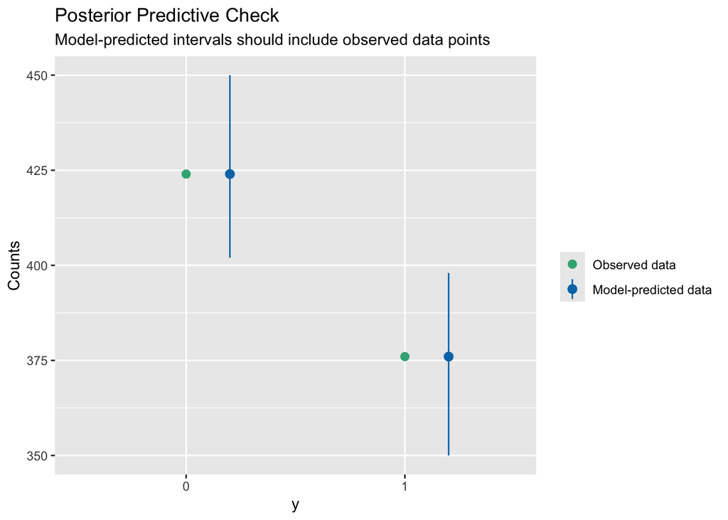

```r
# PPC for the binary logistic model
# plots the density of the observed data against the range of simulated densities
performance::check_predictions(full.mod, iterations = 100)
```

For binary models like this one, the observed data and the range of model-predicted data are shown side-by-side. If the model fits well, the observed data point should fall within the whiskers of the simulated predictions.

```r
# PPC for the misspecified Poisson model
# the observed count distribution is more spread out than the Poisson predicts
performance::check_predictions(poi.ct, iterations = 100)
```

Figure 2: Posterior predictive check for the Poisson count model.

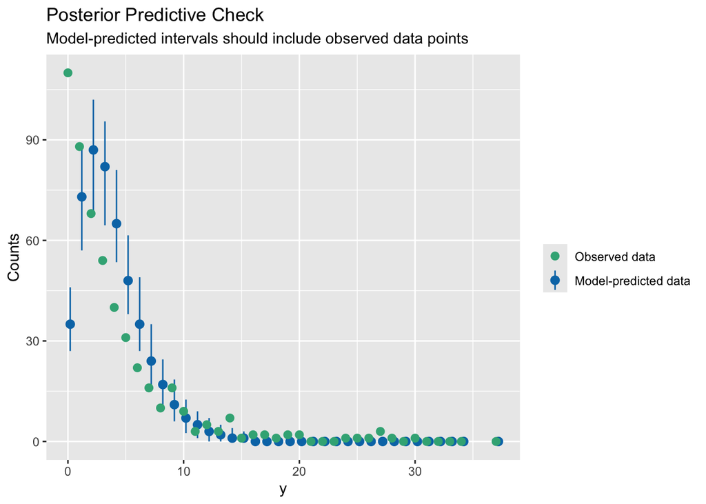

The same thing happens with the Poisson. Here, we know that this model doesn’t fit well on account of the overdispersion. The observed distribution (indicated by the points) falls well outside the whiskers of the simulated predictions, particularly at lower values of $y$. This is an indication of systematic misfit. Again, this is consistent with the overdispersion we built into the data.

This is really cool!

What’s cooler is that you can use this same tool to check the fit of all sorts of different kinds of models. Try it once on a linear model; the plots are actually quite pretty!

### DHARMa as a Formal PPC

Although GLMs don’t have residuals in the way OLS models do. But we can actually simulate residuals that are similar to OLS residuals for the purposes of diagnosing problems with our models. DHARMa’s `testUniformity()` is essentially a formal PPC for the entire residual distribution. If the model is correctly specified, the quantile residuals should be uniform — and the KS test catches systematic departures from that uniformity:

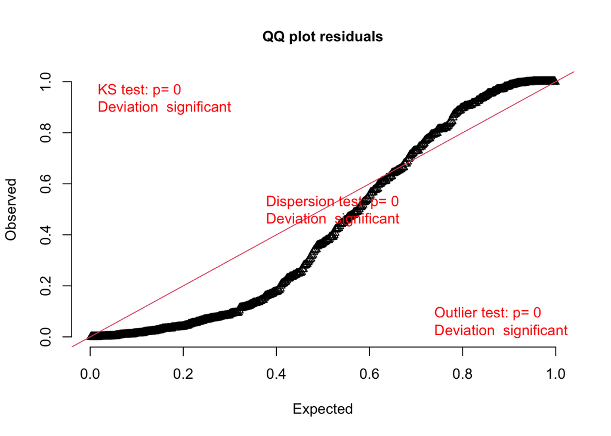

```
##
##  Asymptotic one-sample Kolmogorov-Smirnov test
##
## data:  simulationOutput$scaledResiduals
## D = 0.23, p-value <0.0000000000000002
## alternative hypothesis: two-sided
```

```r
# simulate DHARMa residuals for the Poisson model
sim.poi <- DHARMa::simulateResiduals(poi.ct, n = 500, plot = FALSE)

# testUniformity: KS test + plot
DHARMa::testUniformity(sim.poi,
                        alternative = "two.sided",
                        plot = TRUE)
```

A significant KS test, combined with a PPC that shows systematic mismatch, is strong evidence of model misfit. In this case, both the `check_predictions()` plot and the DHARMa test converge on the same conclusion: the Poisson model is not adequate for these data.

Wow. So this is like a more formal version of the PPC we just did with `performance::check_predictions()`?

It’s not necessarily more formal, but it is more focused on the residual distribution. The `check_predictions()` function is a more general tool that can be used to check any summary statistic of the data against the model’s predictions. The DHARMa test is specifically designed to check the uniformity of the quantile *residuals*, which is a strong diagnostic for overall model fit. Both are valuable tools in your GLM toolkit.

## What About Hosmer-Lemeshow?

For binary logistic regression, the **Hosmer-Lemeshow (HL) test** has historically been the most-reported formal GOF test. It works by grouping observations into $g$ bins based on their predicted probabilities (usually $g = 10$ deciles), computing observed and expected counts within each bin, and running a $\chi^2$ test on the discrepancy:

$$C = \sum_{j=1}^{g} \frac{(O_j - E_j)^2}{E_j}$$

The null hypothesis is good fit. A significant result indicates poor fit in the sense that observed and expected counts differ substantially across some bins.

```r
# Hosmer-Lemeshow test via the performance package
performance::performance_hosmer(full.mod, n_bins = 10)
```

```
## # Hosmer-Lemeshow Goodness-of-Fit Test
##
##   Chi-squared: 7.052
##            df: 8
##       p-value: 0.531
```

This model performs well here. We know that this model is a pretty good fit, though, because we engineered it this way. In practice, the HL test often gives a significant result even when the model is reasonably good, and it often fails to reject even when the model is pretty bad. This is because of several well-known limitations of the test.

Wait. The Hosmer-Lemeshow test is in every GLM textbook I’ve read (okay, ever textbook I’ve *skimmed*). Are you seriously saying I shouldn’t use it?

I’m saying use it *carefully* with a clear understanding of its limitations. The HL test has several well-documented problems:

**It’s sensitive to the number of bins.** The $p$-value can change substantially depending on whether you use 8 or 10 or 12 groups. This makes the test results difficult to replicate and compare.

**It has low power.** The test often fails to reject a null hypothesis of good fit even when the model is substantially misspecified, particularly in small samples.

**It doesn’t penalize overfitting.** A model with too many parameters can produce low predicted probabilities that are spread thinly across bins, making the test nearly impossible to reject.

**In large samples, it rejects too easily.** With enough data, even trivially small and substantively meaningless deviations from perfect fit will be detected.

For all of these reasons, current best practice is to rely primarily on **posterior predictive checks** and **DHARMa-based tests**, and to treat the HL test as supplementary context rather than the main evidence of fit. If your reviewers ask for it, report it — but don’t let it substitute for a more comprehensive assessment.

> The Hosmer-Lemeshow test was state-of-the-art in the 1980s. It remains useful as a quick sanity check, but it should not be the primary basis for evaluating a logistic regression’s fit in contemporary applied work.

## Goodness of Fit in Mixed Models

Mixed models add complexity to every aspect of fit assessment. The core issue is that there are now *two levels* at which we can ask “how well does the model fit?” — the within-group level (how well do we predict individual observations?) and the between-group level (how well do the model’s predictions capture group-level patterns?). This distinction drives everything in this section.

So our single-level model tools don’t just carry over to mixed models? That sounds like a pain.

It is a bit more work, but the tools are there. We just have to be careful about what we’re asking at each step.

### Marginal vs. Conditional $R^2$

Nakagawa and Schielzeth (2013) proposed a framework for $R^2$ in mixed models that captures this two-level distinction. The **marginal** $R^2$ ($R^2_m$) captures the variance explained by the *fixed effects alone*. It answers the question “how much of the variance in $Y$ is explained by our predictors, ignoring the clustering structure?”

The **conditional** $R^2$ ($R^2_c$) captures the variance explained by *both fixed and random effects*. It answers the question “how much of the variance in $Y$ is explained by our full model, including the group-level structure?”

$$R^2_c \geq R^2_m \quad \text{always}$$

The gap between them is informative: a large gap means the random effects are explaining a substantial amount of variance that the fixed effects alone don’t capture. A small gap means the group structure adds little once the individual-level predictors are accounted for.

```r
# performance::r2() returns both marginal and conditional R² for lme4 objects
r2(full.glmm)
```

```
## # R2 for Mixed Models
##
##   Conditional R2: 0.316
##      Marginal R2: 0.103
```

```r
# examine how the random effect contributes to fit
r2.null <- r2(null.glmm)
r2.full <- r2(full.glmm)

r2.tbl <- data.frame(
  Model       = c("Null (intercept + RE only)", "Full (predictors + RE)"),
  R2_marginal = c(NA, round(r2.full$R2_marginal, 3)),
  R2_cond     = c(round(r2.null$R2_conditional, 3),
                  round(r2.full$R2_conditional, 3))
)

kable(r2.tbl,
      col.names = c("Model", "R² (marginal)", "R² (conditional)"),
      caption   = "Marginal and conditional R² for mixed models",
      na = "—") %>%
  kable_styling(bootstrap_options = c("striped", "hover"),
                full_width = FALSE)
```

Table 7: Table 8: Marginal and conditional R² for mixed models

|  | Model | R² (marginal) | R² (conditional) |
| --- | --- | --- | --- |
|  | Null (intercept + RE only) |  | 0.212 |
| Marginal R2 | Full (predictors + RE) | 0.103 | 0.316 |

In the null model (no predictors), the marginal $R^2$ is undefined (or zero), because there are no fixed predictors. The conditional $R^2$ from the null model is equivalent to the ICC. It tells you how much variance is accounted for by group membership alone. This is why reporting the ICC from the null model alongside the marginal and conditional $R^2$ from the full model gives a coherent narrative: the ICC tells you how much clustering matters in the raw data; the difference between $R^2_m$ and $R^2_c$ tells you how much the random effects contribute on top of your fixed predictors.

That makes a lot of sense. So the marginal $R^2$ is like the “fixed effects $R^2$” and the conditional $R^2$ is like the “full model $R^2$”?

Sort of. Except that the marginal $R^2$ captures the explanatory power of the fixed effects alone, while the conditional $R^2$ captures the explanatory power of the entire model, including both fixed and random effects. Comparing them helps you understand how much of the variance is explained by the predictors versus the group-level structure. It also gives you a sense of how important the random effects are in your model. If the marginal and conditional $R^2$ are close, it means the fixed effects are doing most of the work. If there’s a big gap, it means the random effects are capturing a lot of variance that the fixed effects aren’t.

### AIC and BIC for Mixed Models

AIC and BIC work for mixed models estimated via maximum likelihood (`REML = FALSE` in `lmer()`), but there’s an important caveat: **models estimated with REML (restricted maximum likelihood) cannot be compared using likelihood-based criteria** if they differ in their fixed effects structure.

```r
# for comparing models with different fixed effects:
# refit with REML = FALSE (ML estimation) first
# lmer() uses REML by default; glmer() uses ML by default

# for glmer objects (used in our GLMM), ML is the default — AIC/BIC are valid
AIC(null.glmm, full.glmm)
```

```
##           df    AIC
## null.glmm  2 1016.1
## full.glmm  4  950.4
```

```r
BIC(null.glmm, full.glmm)
```

```
##           df    BIC
## null.glmm  2 1025.5
## full.glmm  4  969.1
```

```r
# for random effects structure comparisons (same fixed effects, different RE):
# REML is appropriate — use as estimated
# compare with anova() or lrtest()
lmtest::lrtest(null.glmm, full.glmm)
```

```
## Likelihood ratio test
##
## Model 1: y ~ 1 + (1 | country)
## Model 2: y ~ x.ind + x.ctry + (1 | country)
##   #Df LogLik Df Chisq          Pr(>Chisq)
## 1   2   -506
## 2   4   -471  2  69.7 0.00000000000000073 ***
## ---
## Signif. codes:  0 '***' 0.001 '**' 0.01 '*' 0.05 '.' 0.1 ' ' 1
```

### The ICC Revisited as a Fit Metric

The **intraclass correlation coefficient** (ICC) from the null model deserves a brief reprise in the context of fit, because it’s one of the most substantively meaningful summaries of how well a mixed model is warranted by the data.[^3]

For a binary GLMM, using the latent variable approach:

$$\text{ICC} = \frac{\tau_{00}}{\tau_{00} + \pi^2/3}$$

```r
# extract between-group variance from the null GLMM
tau00 <- as.numeric(VarCorr(null.glmm)$country)

# ICC via latent variable formula (binary model)
icc.val <- tau00 / (tau00 + pi^2 / 3)

cat("Between-group variance (tau_00):", round(tau00, 4), "\n")
```

```
## Between-group variance (tau_00): 0.8839
```

```r
cat("ICC:                            ", round(icc.val, 3), "\n")
```

```
## ICC:                             0.212
```

```r
# performance::icc() does the same thing (cleaner output)
performance::icc(null.glmm)
```

```
## # Intraclass Correlation Coefficient
##
##     Adjusted ICC: 0.212
##   Unadjusted ICC: 0.212
```

An ICC of 0.21 means that 21% of the total variance in the outcome is explained by country membership alone, before we’ve added any individual-level predictors. That’s a strong justification for the mixed model approach; ignoring that clustering would give badly wrong standard errors. An ICC near zero means the grouping variable isn’t doing much, and a simpler model might be sufficient.

So the ICC is like a measure of how much clustering matters in the data? If it’s high, we really need to use a mixed model, right?

Exactly. A high ICC means that a large portion of the variance in the outcome is due to differences between groups (countries, in this case). This justifies the use of a mixed model because it indicates that observations within the same group are more similar to each other than to observations from different groups. If the ICC were close to zero, it would suggest that the grouping variable isn’t contributing much to explaining the variance, and a simpler model without random effects might be sufficient.

Now, let’s recap!

## Summary

```r
summ.tbl <- data.frame(
  Tool = c(
    "Null & residual deviance",
    "G statistic (LR test vs. null)",
    "McFadden's R²",
    "Tjur's R² (binary only)",
    "Nagelkerke R²",
    "AIC / BIC",
    "LR test (lrtest())",
    "compare_performance()",
    "check_predictions() (PPC)",
    "DHARMa testUniformity()",
    "Hosmer-Lemeshow test",
    "Marginal / Conditional R² (mixed)",
    "ICC (mixed)"
  ),
  Use_for = c(
    "Understanding overall model fit on the likelihood scale",
    "Overall significance: do any predictors help?",
    "Relative fit; proportion of log-likelihood explained",
    "Discrimination ability in binary models; easy to interpret",
    "Relative fit; comparable to R² in scale (not meaning)",
    "Comparing nested or non-nested models; model selection",
    "Formal test for nested model comparison",
    "Side-by-side comparison across multiple models",
    "Absolute fit: does the model reproduce the data distribution?",
    "Formal PPC: are residuals uniform under the model?",
    "Historical GOF test for logistic regression; use cautiously",
    "Variance explained at fixed-effects and full-model levels",
    "Justification for mixed model; clustering strength"
  ),
  Key_function = c(
    "`glm()$deviance`, `glm()$null.deviance`",
    "`anova(m0, m1, test='Chisq')`",
    "`rcompanion::nagelkerke()`",
    "`performance::r2()`",
    "`rcompanion::nagelkerke()`",
    "`AIC()`, `BIC()`",
    "`lmtest::lrtest()`",
    "`performance::compare_performance()`",
    "`performance::check_predictions()`",
    "`DHARMa::testUniformity()`",
    "`performance::performance_hosmer()`",
    "`performance::r2()` on lme4 object",
    "`performance::icc()`"
  )
)

kable(summ.tbl,
      col.names = c("Tool", "Use it for", "Key R function"),
      caption   = "Quick reference: goodness-of-fit tools for GLMs and GLMMs") %>%
  kable_styling(bootstrap_options = c("striped", "hover"),
                full_width = FALSE) %>%
  column_spec(1, bold = TRUE)
```

Table 9: Table 10: Quick reference: goodness-of-fit tools for GLMs and GLMMs

| Tool | Use it for | Key R function |
| --- | --- | --- |
| Null & residual deviance | Understanding overall model fit on the likelihood scale | `glm()$deviance`, `glm()$null.deviance` |
| G statistic (LR test vs. null) | Overall significance: do any predictors help? | `anova(m0, m1, test='Chisq')` |
| McFadden’s R² | Relative fit; proportion of log-likelihood explained | `rcompanion::nagelkerke()` |
| Tjur’s R² (binary only) | Discrimination ability in binary models; easy to interpret | `performance::r2()` |
| Nagelkerke R² | Relative fit; comparable to R² in scale (not meaning) | `rcompanion::nagelkerke()` |
| AIC / BIC | Comparing nested or non-nested models; model selection | `AIC()`, `BIC()` |
| LR test (lrtest()) | Formal test for nested model comparison | `lmtest::lrtest()` |
| compare_performance() | Side-by-side comparison across multiple models | `performance::compare_performance()` |
| check_predictions() (PPC) | Absolute fit: does the model reproduce the data distribution? | `performance::check_predictions()` |
| DHARMa testUniformity() | Formal PPC: are residuals uniform under the model? | `DHARMa::testUniformity()` |
| Hosmer-Lemeshow test | Historical GOF test for logistic regression; use cautiously | `performance::performance_hosmer()` |
| Marginal / Conditional R² (mixed) | Variance explained at fixed-effects and full-model levels | `performance::r2()` on lme4 object |
| ICC (mixed) | Justification for mixed model; clustering strength | `performance::icc()` |

A note on workflow: the tools in this table are complementary, not redundant. In a real analysis, you’ll use them in sequence — deviance and $G$ to establish that your predictors collectively matter, AIC/BIC or LRT to compare competing specifications, pseudo-$R^2$ for a descriptive summary, and PPCs to check whether the model is adequate in an absolute sense. Don’t pick one and ignore the rest.

## References

Nakagawa, Shinichi, and Holger Schielzeth. 2013. “A General and Simple Method for Obtaining R² from Generalized Linear Mixed-Effects Models.” *Methods in Ecology and Evolution* 4 (2): 133–42. https://doi.org/10.1111/j.2041-210x.2012.00261.x.

Tjur, Tue. 2009. “Coefficients of Determination in Logistic Regression Models — a New Proposal: The Coefficient of Discrimination.” *The American Statistician* 63 (4): 366–72. https://doi.org/10.1198/tast.2009.08210.

[^1]: Notice the sign convention. The log-likelihood is always negative (or zero), and $\ell_{\text{sat}} \geq \ell(\hat{\boldsymbol{\beta}})$ always, so $D \geq 0$. Under the null hypothesis that the fitted model is correctly specified, $D$ is asymptotically distributed as $\chi^2$ with degrees of freedom equal to the difference in the number of parameters between the saturated and fitted models — i.e., $n - k$.
[^2]: McFadden originally proposed this in the context of discrete choice models, not GLMs generally. The formula extends naturally to any likelihood-based model. The “proportion of log-likelihood explained” interpretation is the most accurate way to describe it. It’s not a proportion of variance, despite what some textbook descriptions imply.
[^3]: The ICC is covered in more depth in the companion page on mixed model diagnostics. Here, we’re treating it as a fit metric rather than a diagnostic.